# Final Project Report

PSTAT100: Data Science Concepts and Analysis

Author

Quarter

Group 1

Fall 2024

**STUDENT NAME**

- Sara Li (sara931)
- Caitlyn Vasquez (cnv988)
- Andy Zhang (yinuozhang)
- Julian Leon (jleon)
- Justin Vy (jvy)

# 1 Introduction and Overview

## 1.1 Research Questions

**Question 1:** Which lifestyle factors (e.g., stress level, physical activity, BMI, and daily steps) are most likely to contribute to the development of sleep disorders?

**Question 2:** How does the level of physical activity influence the quality of sleep across different age groups?

**Question 3:** How does the interaction between stress level and occupation type impact overall sleep duration?

## 1.2 Hypotheses

**Hypothesis 1:**

*NULL Hypothesis:* $H_0: \beta_{stress level} = \beta_{physical activity} = \beta_{BMI} = \beta_{daily steps} = 0$  
None of the lifestyle factors significantly contribute to the development of sleep disorders.

*Alternative Hypothesis:* $H_A:$ At least one of $\beta_{stress level} , \beta_{physical activity} , \beta_{BMI} , \beta_{daily steps} \ne0$  
At least one of the lifestyle factors significantly contributes to the development of sleep disorders. Specifically, higher stress levels and BMI (Overweight/Obese) and lower physical activity levels and daily steps increases the likelihood of sleep disorders. We hypothesize that stress level will have the strongest influence.

**Hypothesis 2:**

*NULL Hypothesis:* $H_0: \beta_{physical activity \times age group} = 0$  
There is no interaction between physical activity level and age group on sleep quality.

*Alternative Hypothesis:* $H_A: \beta_{physical activity \times age group} \ne 0$  
There is a significant interaction effect between physical activity level and age group on sleep quality.

**Hypothesis 3:**

*NULL Hypothesis:* $H_0: \beta_{stress levels \times occupation} = 0$  
There is no significant interaction effect between stress level and occupation type on sleep duration.

*Alternative Hypothesis:* $H_A: \beta_{stress levels \times occupation} \ne 0$  
There is a significant interaction effect between stress level and occupation type on sleep duration.

There are 13 variables in this dataset and 374 observations. Out of the 13 variables, 8 are numeric (Person.ID, Age, Sleep.Duration, Quality.of.Sleep, Physical.Activity.Level, Stress.Level, Heart.Rate, and Daily.Steps), and 5 are character variables (Gender, Occupation, BMI.Category, Blood.Pressure, and Sleep.Disorder).

Our analysis of this dataset allows us to explore the effects of various factors (physical activity, the presence of a sleep disorder, BMI, etc) have on sleep quality/sleep duration and vice versa. This makes the dataset suitable for regression analysis as we are able to take a deeper dive into the relationships between these variables and how strong the variables’ influence is. From this, we are able to visualize and build models to represent these relationships.

# 2 Modeling Process:

1. Logistic Regression  
   For question 1, we want to use a classification technique since our response variable (sleep disorder) is binary (yes or no). For preprocessing and simplification purposes, we coded sleep disorder to be binary based on whether a sleep disorder was present (Yes = Insomnia or Sleep Apnea) or not present (No = None). Considering that we want to see if any of the lifestyle factors have a significant impact on the development of sleep disorders and categorically predict the outcome variable, logistic regression is suitable. Logistic regression allows us to interpret the results in terms of odds ratios, which provides insights on how a one-unit change in predictor variable affects the odds of the response being “Yes” (i.e. having a sleep disorder). Interpreting the coefficients allows us to analyze which variables increase the development of a sleep disorder based on the individual p-value and what relationship the predictor variables have on the response (e.g. positive, negative). Logistic regression can also handle both numerical predictors (stress level, physical activity level, and daily steps) as well as categorical predictors (BMI) making it ideal for question 1.
2. ANOVA  
   Regarding questions 2 and 3, ANOVA is ideal because the model can handle interactions. In both questions we want to determine whether or not the interaction is significant and a two-way ANOVA can evaluate how the combination of the two predictor factors influence the response. ANOVA is also designed to test differences in means when predictors are categorical (e.g. age group, occupation type) even when the other variables (including the response) are numerical. The F-statistic and p-value of the model is a simple and straightforward way of testing our hypothesis.

## 2.1 EDA Visualization and Communication

*Question 1.*

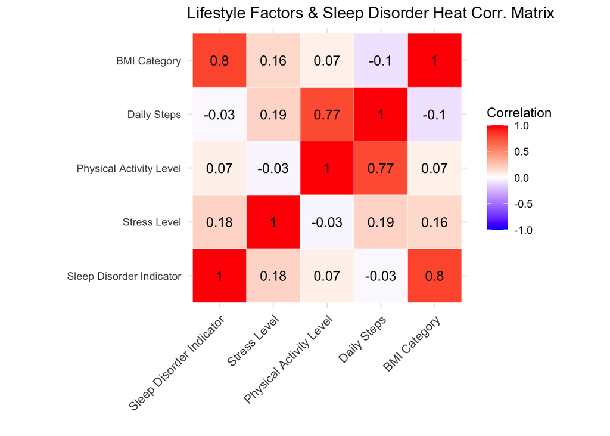

The heat map shows that there is a strong positive correlation (0.8) between the sleep disorder indicator and the BMI category. This suggests that those with a higher BMI (Overweight/Obese) are at a higher risk of having a sleep disorder compared to those with a “Normal” BMI. There is also a strong positive correlation (0.77) between daily steps and physical activity level which makes logical sense.

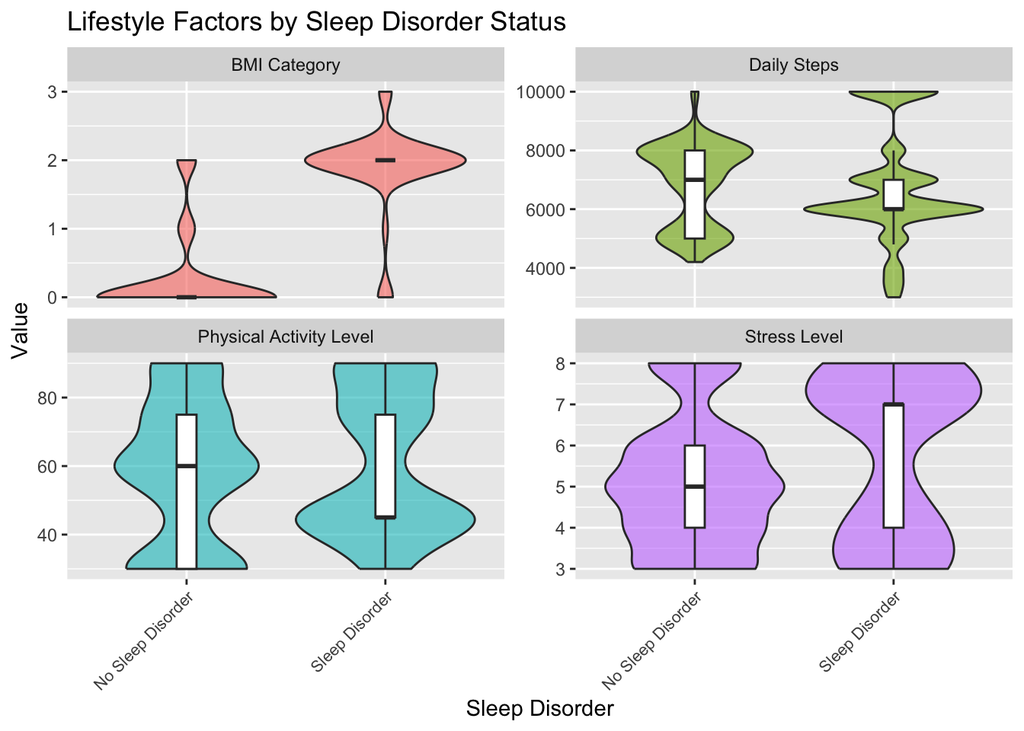

For the above Violin plot with included boxplot compares the distributions of each lifestyle factor with and without a sleep disorder. In the Daily Steps plot, individuals with sleep disorders have a wider range of daily steps; from 3000 to 10000 steps. The data are distributed through the lower range and to the higher range. This shows that extreme low or high daily steps could be associated with sleep disorders. For individuals with no sleep disorder, the distribution is narrower, with most data points concentrated between 6000 and 8000 steps, indicating that medium level of daily steps have less correlation with sleep disorders.

The distribution of Physical Activity Level has a central concentration of around 60 for people with no sleep disorder, while the concentration is around 45 for those with sleep disorders. This shows that most individuals with a sleep disorder status fall under the lower levels of physical activity.

The Stress Level distribution is narrower, and both groups are within the 5 levels. Individuals with sleep disorders have slightly higher values in the upper range (6-8). Individuals without sleep disorders are more concentrated around the median level (4-6). It is reasonable to assume that increased stress levels have a high chance of being associated with sleep disorders.

The distribution of BMI Category has a very dense central concentration at ‘normal’ (0) for people without sleep disorders. We can see that there doesn’t exist any individuals in the dataset that are obese (3) without a sleep disorder. For individuals with sleep disorders, we can see the distribution shift upwards towards the higher end of the BMI scale, ‘Overweight’ (2) and ‘Obese’ (3). This shows that individuals with a worse BMI are more susceptible to sleep disorders.

*Question 2.*

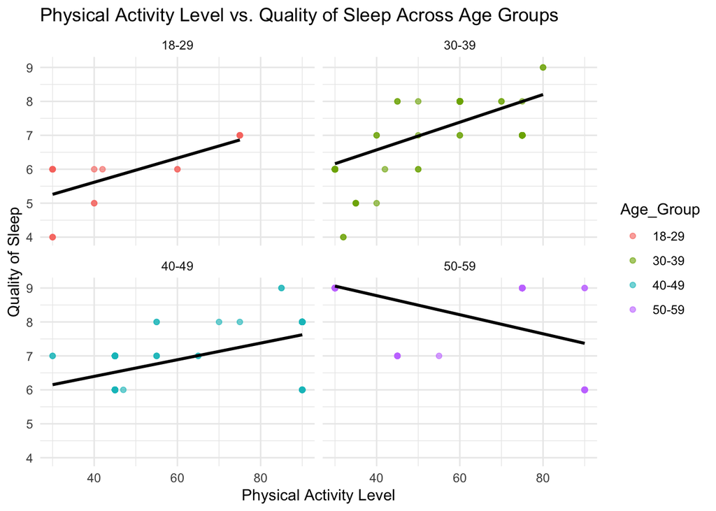

1. **Age Group 18-29**: There is a positive relationship between physical activity level and quality of sleep. Higher physical activity levels tend to be associated with better sleep quality, as shown by the upward slope of the regression line.
2. **Age Group 30-39**: Similar to the 18-29 group, there is a positive trend, suggesting that higher physical activity is associated with higher sleep quality. The points are more spread out in this group, indicating more variability in sleep quality at different physical activity levels.
3. **Age Group 40-49**: This group also shows a slight positive trend, though it appears less pronounced than in younger age groups. Increased physical activity still appears to correlate with slightly better sleep quality.
4. **Age Group 50-59**: Interestingly, this age group shows a negative relationship between physical activity level and quality of sleep. Higher physical activity seems associated with a slight decrease in sleep quality, as indicated by the downward slope of the regression line. This could suggest that, for this age group, factors other than physical activity may play a more significant role in determining sleep quality, or high activity levels might have a different impact on sleep at older ages.

*Question 3.*

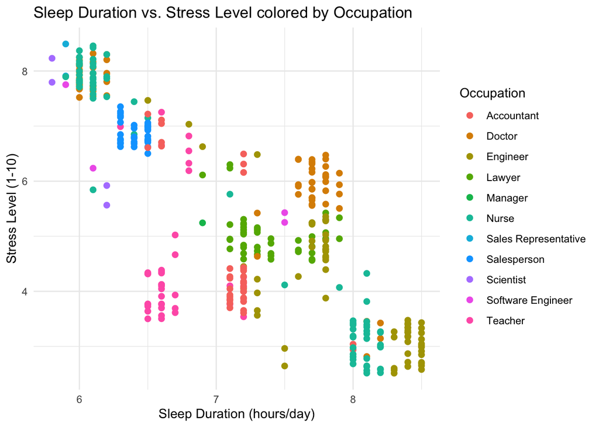

We speculated that individuals in high-stress occupations, such as healthcare, experience less hours sleeping compared to those in lower-stress jobs. Our assumption was both correct and incorrect because some individuals with healthcare occupations (i.e. nurses and doctors) that report high stress levels get less hours of sleep (our hypothesis) but other individuals with the same occupations that report low stress levels get more hours of sleep. This might lead us to analyze other factors such as work environment, work-life balance, coping mechanisms/mental health, and occupational experience.

## 2.2 Results/Interpretation

*Question 1.*

To preprocess the data, we cleaned the names of the dataset and modified it by converting the `Sleep Disorder` column to a binary factor variable (Yes or No). For this question, we want to conduct logistic regression. But first, we must check assumptions which are: (1) linearity of log-odds, (2) absence of multicollinearity, and (3) lack of strongly influential points. We know that each observation is independent so we don’t need to check for independence of errors.

### 2.2.1 Linearity of Log-Odds

```
                                                   Coefficient     p.values
                                                   (Intercept) 8.879529e-01
                                                  stress_level 3.246039e-01
                                       physical_activity_level 5.087763e-01
                                     bmi_categoryNormal Weight 3.382248e-02
                                             bmi_categoryObese 9.865610e-01
                                        bmi_categoryOverweight 4.653297e-22
                                                   daily_steps 7.310839e-01
                       I(stress_level * log(stress_level + 1)) 3.018338e-01
 I(physical_activity_level * log(physical_activity_level + 1)) 4.949070e-01
                         I(daily_steps * log(daily_steps + 1)) 7.289807e-01
```

Looking at a summary of the model with interaction terms, we can see from the p-values that none of the interaction terms are significant (p-value < $\alpha = 0.05$) so the linearity assumption is met.

### 2.2.2 No Multicollinearity

```
                            GVIF Df GVIF^(1/(2*Df))
stress_level            1.241294  1        1.114134
physical_activity_level 3.439301  1        1.854535
bmi_category            1.033844  3        1.005563
daily_steps             3.350754  1        1.830507
```

None of the VIF values are greater than 10 so the assumption of no multicollinearity is met.

### 2.2.3 No Influential Points

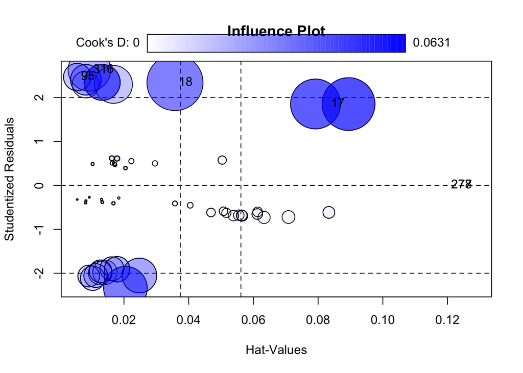

```
         StudRes         Hat        CookD
17  1.8500271757 0.089408138 5.594731e-02
18  2.3395210531 0.035761971 6.306209e-02
95  2.4650134160 0.005548140 1.506775e-02
277 0.0004215025 0.128696544 2.003344e-09
278 0.0004215025 0.128696544 2.003344e-09
316 2.6274260259 0.009313345 3.635290e-02
```

```
[1] "Number of influential points: 62"
```

```
[1] "Total number of points: 374"
```

Using the `influence.measures()` function, we can extract the number of influential points. We found that there are 62 influential points out of 374 points total. Although there is quite a lot of influential points, the influence plot shows that none of points exceed a Cook’s distance of 1 which would suggest potential influence. Thus, the assumption of no influential points is met.

## 2.3 Visualization of Model Performance

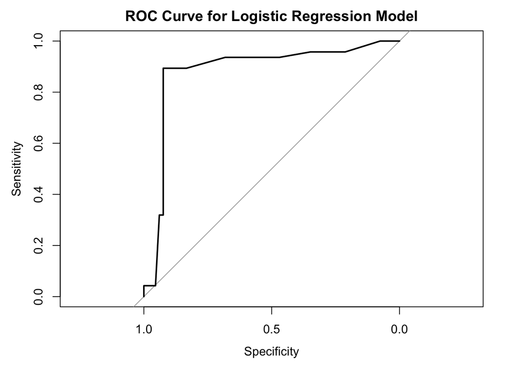

```
Area under the curve: 0.8825
```

The ROC curve plots the true positive rate (sensitivity) against the false positive rate (1 - specificity) for different classification thresholds. The plot confirms that our model has strong predictive capabilities because it achieves high sensitivity and specificity. This is indicated by the curve being relatively close to the upper-left corner. The AUC value is 0.8825 implying that there is an 88.25% chance that the model will correctly rank a positive instance higher than a negative one.

```
          Truth
Prediction No Yes
       No  61   5
       Yes  5  42
```

The confusion matrix also indicates that our model has high accuracy due to the few false positives/negatives (5 each) and well-balanced sensitivity/specificity. The model diagnostics show that our model performs very well.

## 2.4 Summary of Model

```
# A tibble: 6 × 6
  term                       estimate std.error statistic  p.value odds_ratio
  <chr>                         <dbl>     <dbl>     <dbl>    <dbl>      <dbl>
1 (Intercept)                  -0.780     0.229     -3.41 6.39e- 4      0.458
2 physical_activity_level       1.33      0.350      3.81 1.40e- 4      3.79
3 stress_level                  0.796     0.225      3.53 4.16e- 4      2.22
4 daily_steps                  -1.69      0.347     -4.87 1.10e- 6      0.184
5 bmi_category_Normal.Weight    0.193     0.177      1.10 2.73e- 1      1.21
6 bmi_category_Overweight       2.22      0.237      9.34 9.20e-21      9.18
```

Overall, the best logistic regression model produced an accuracy of 91.5%, which we used on our testing data to see how accurate the predictions are. The final logisitic regression model on the testing set produced an accuracy of 91.2%, which is a strong performance. Our evaluation metrics also performed well and indicated that our model is a good fit.

Given a significance level of 0.05, all of the variables are significant except the “normal weight” BMI category because the p-value > 0.05. Therefore, we reject our null hypothesis and conclude that at least one of the lifestyle factors significantly contributes to the development of sleep disorders. From the significant variables, the summary shows that increased physical activity levels, increased stress levels, decreased daily steps, and being overweight (independent of one another) increases the chance of having a sleep disorder. This is indicated by the positive/negative estimate value where positive signifies increase and negative signifies decrease. This is consistent with our hypothesis in all variables except the physical activity level. Contrary to our hypothesis that suggests lower physical activity should increase the likelihood of sleep disorders, the coefficient indicates that higher physical activity increases likelihood of sleep disorders. We also hypothesized that the “Obese” BMI category would have a significant affect in addition to the “Overweight” BMI category but since there are very few observations under “Obese” this makes logical sense.

To address the other part of our hypothesis that stress level has the strongest influence, we can look at the odds ratio and p-value. A higher odds ratio and a low p-value signifies a more influential factor. The most influential factor appears to be BMI (Overweight) with the highest odds ratio of 9.18 and the lowest p-value of 9.20e-21. So, our hypothesis that stress level is most indicative of having a sleep disorder is incorrect.

*Question 2.*

```
Diagnostics for: With Interaction

Shapiro-Wilk Test for Normality (Residuals):

    Shapiro-Wilk normality test

data:  residuals(current_model_2)
W = 0.9438, p-value = 1.045e-10
```

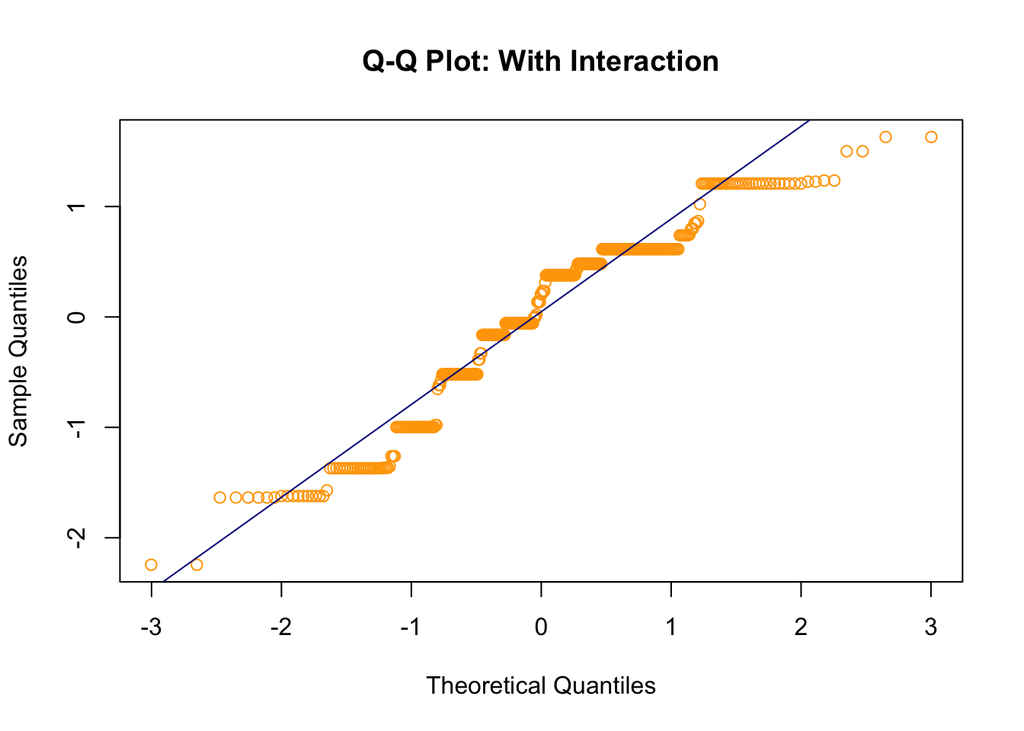

```
Breusch-Pagan Test for Homogeneity of Variance:

    studentized Breusch-Pagan test

data:  current_model_2
BP = 133.8, df = 7, p-value < 2.2e-16
```

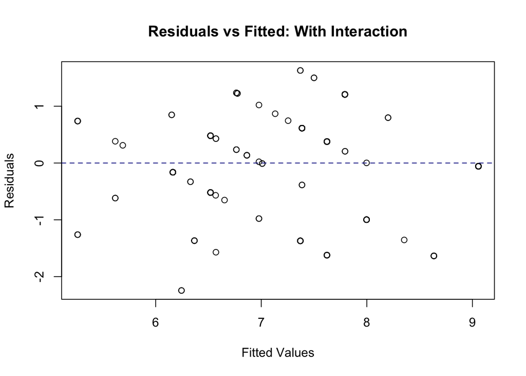

```
Durbin-Watson Test for Independence:

    Durbin-Watson test

data:  current_model_2
DW = 0.55419, p-value < 2.2e-16
alternative hypothesis: true autocorrelation is greater than 0


Diagnostics for: Without Interaction

Shapiro-Wilk Test for Normality (Residuals):

    Shapiro-Wilk normality test

data:  residuals(current_model_2)
W = 0.87295, p-value < 2.2e-16
```

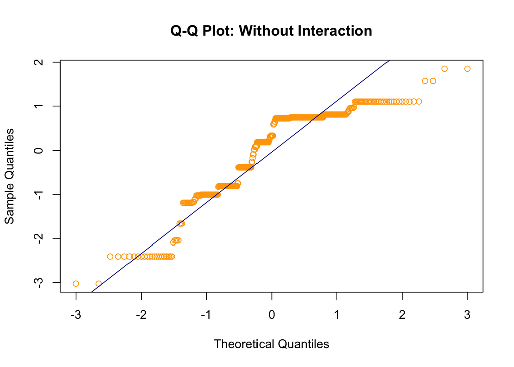

```
Breusch-Pagan Test for Homogeneity of Variance:

    studentized Breusch-Pagan test

data:  current_model_2
BP = 65.185, df = 4, p-value = 2.352e-13
```

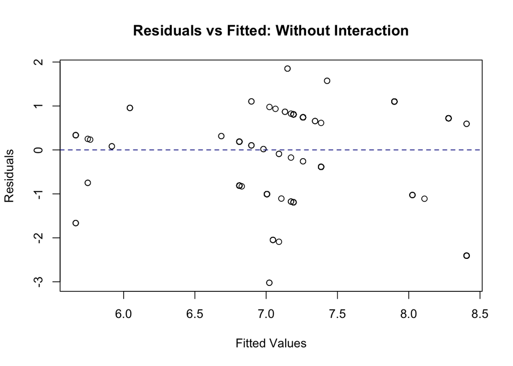

```
Durbin-Watson Test for Independence:

    Durbin-Watson test

data:  current_model_2
DW = 0.59244, p-value < 2.2e-16
alternative hypothesis: true autocorrelation is greater than 0
```

```
Model Comparison:
```

```
AIC with Interaction: 944.7389
```

```
AIC without Interaction: 1093.005
```

```
BIC with Interaction: 980.0572
```

```
BIC without Interaction: 1116.551
```

```
# Comparison of Model Performance Indices

Name        | Model |  AIC (weights) | AICc (weights) |  BIC (weights) |    R2 | R2 (adj.) |  RMSE | Sigma
----------------------------------------------------------------------------------------------------------
model_2     |    lm |  944.7 (>.999) |  945.2 (>.999) |  980.1 (>.999) | 0.512 |     0.502 | 0.835 | 0.844
new_model_2 |    lm | 1093.0 (<.001) | 1093.2 (<.001) | 1116.6 (<.001) | 0.262 |     0.254 | 1.027 | 1.034
```

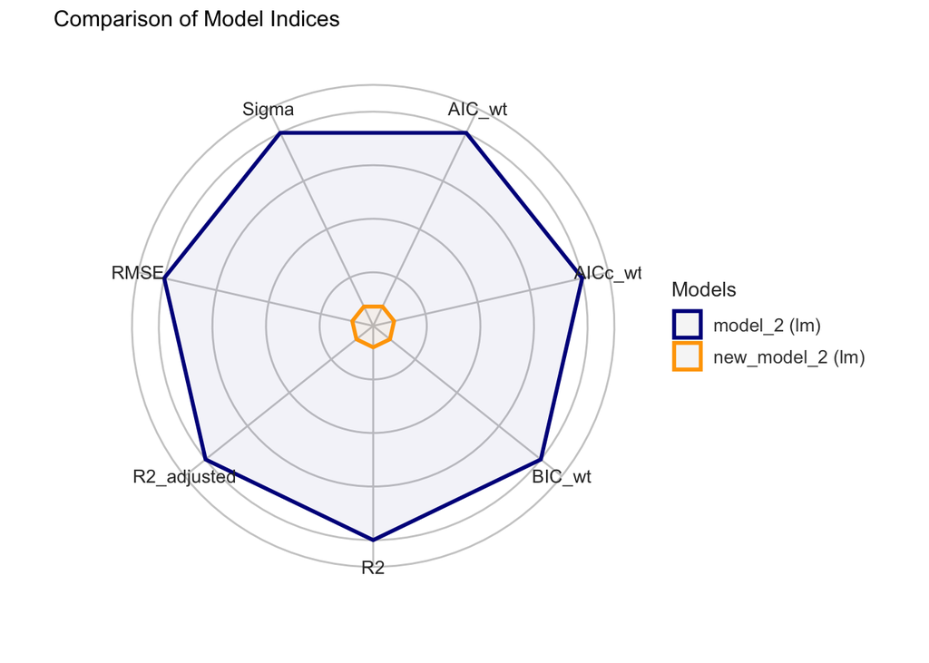

```
Analysis of Variance Table

Model 1: Quality.of.Sleep ~ Age_Group * Physical.Activity.Level
Model 2: Quality.of.Sleep ~ Age_Group + Physical.Activity.Level
  Res.Df    RSS Df Sum of Sq      F    Pr(>F)
1    366 260.94
2    369 394.16 -3   -133.22 62.288 < 2.2e-16 ***
---
Signif. codes:  0 '***' 0.001 '**' 0.01 '*' 0.05 '.' 0.1 ' ' 1
```

[figure not shown]

More physical exercise was associated with improved sleep quality for younger adults—especially those between the ages of 18 and 29. But among older people—especially those between the ages of 50 and 59—the reverse was true. Higher degrees of physical activity in this group were in fact linked to worse sleep quality. This implies that, whether in response to physical strain, health problems, or recovery difficulties, the advantages of exercise for sleep could drop or even reverse as people age.

Our model’s interaction terms verified that age is clearly important in this connection. For instance, whereas in younger groups physical activity regularly enhanced sleep quality, the negative effect shown in the 50–59 age group emphasizes just how drastically exercise may alter sleep depending on age.

Comparing models, the one with interaction terms obviously did better. About half of the variance in sleep quality (approximately 51.2%), was explained by it; the simpler model without interactions only explained around 26%. The more complicated model was also superior in forecasting sleep quality throughout all age groups as its error margin was less.

Said otherwise, we did find several problems with the presumptions of the model. For example, the residuals—that is, the variations between observed and expected values—were not quite normal, and group heterogeneity in errors was not uniform. These problems imply that the model has potential for development, but they do not diminish the basic conclusion: age greatly influences the way physical exercise affects the quality of sleep.

*Question 3.*

```
Analysis of Variance Table

Response: Sleep.Duration
                         Df  Sum Sq Mean Sq  F value    Pr(>F)
Stress.Level              1 155.320 155.320 2301.407 < 2.2e-16 ***
Occupation               10  44.121   4.412   65.375 < 2.2e-16 ***
Stress.Level:Occupation   7  12.736   1.819   26.958 < 2.2e-16 ***
Residuals               355  23.959   0.067
---
Signif. codes:  0 '***' 0.001 '**' 0.01 '*' 0.05 '.' 0.1 ' ' 1
```

```
Analysis of Variance Table

Response: Sleep.Duration
              Df  Sum Sq Mean Sq  F value    Pr(>F)
Stress.Level   1 155.320 155.320 1532.278 < 2.2e-16 ***
Occupation    10  44.121   4.412   43.527 < 2.2e-16 ***
Residuals    362  36.694   0.101
---
Signif. codes:  0 '***' 0.001 '**' 0.01 '*' 0.05 '.' 0.1 ' ' 1
```

```
Diagnostics for: With Interaction

Shapiro-Wilk Test for Normality (Residuals):

    Shapiro-Wilk normality test

data:  residuals(current_model_3)
W = 0.93826, p-value = 2.396e-11
```

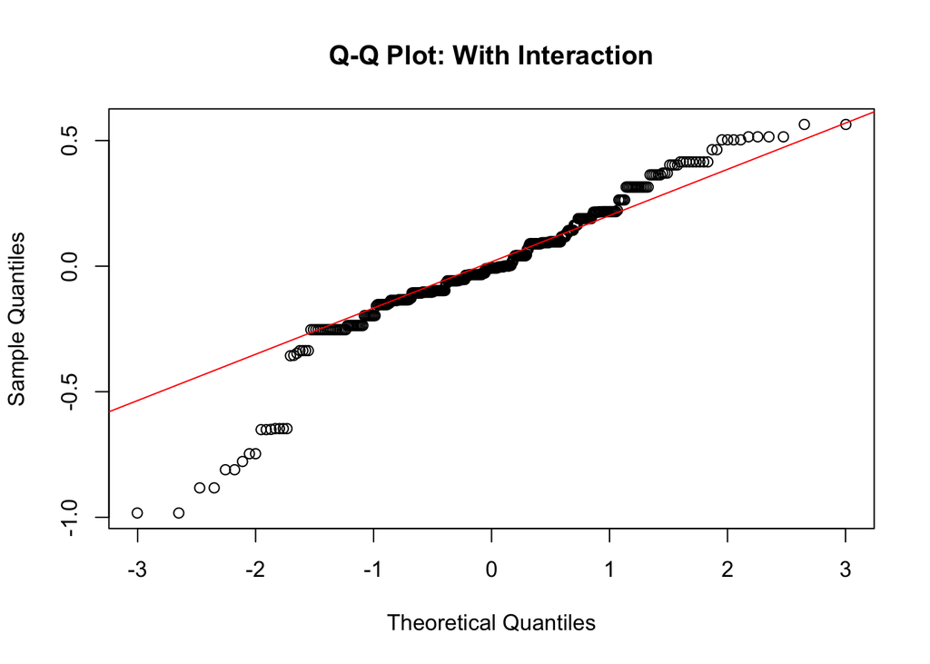

```
Breusch-Pagan Test for Homogeneity of Variance:

    studentized Breusch-Pagan test

data:  current_model_3
BP = 156.45, df = 18, p-value < 2.2e-16
```

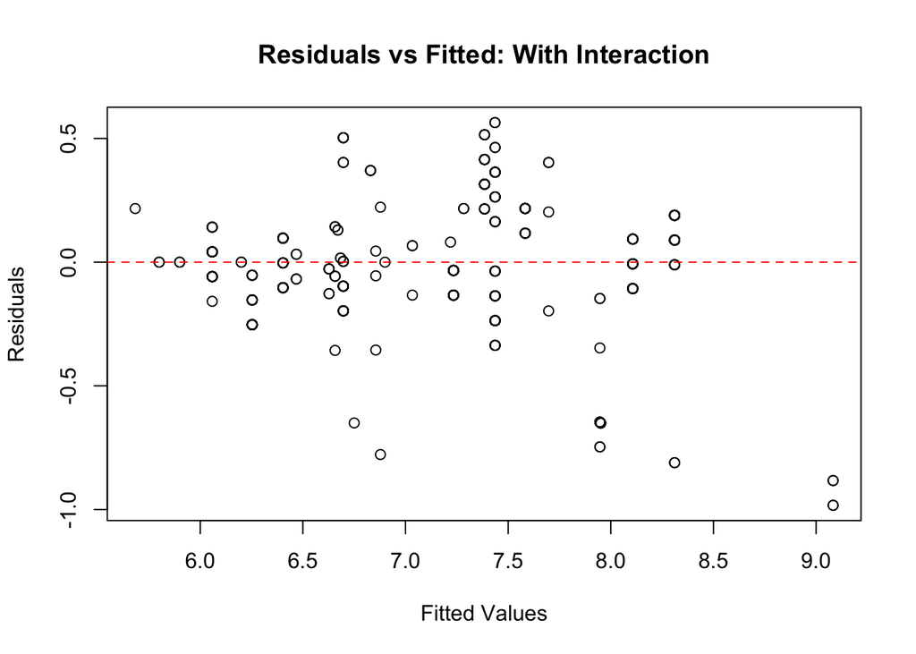

[output not shown]

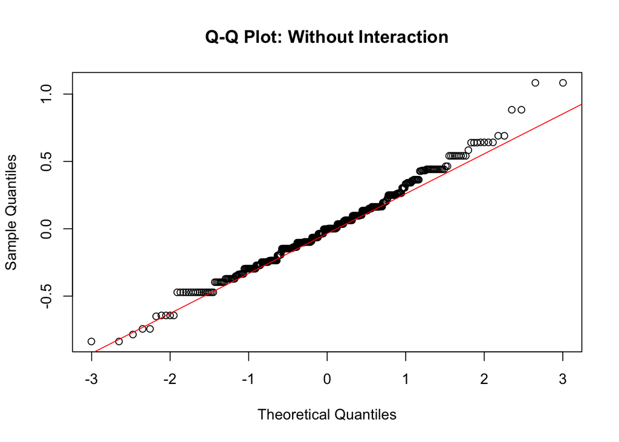

```
Breusch-Pagan Test for Homogeneity of Variance:

    studentized Breusch-Pagan test

data:  current_model_3
BP = 96.1, df = 11, p-value = 1.053e-15
```

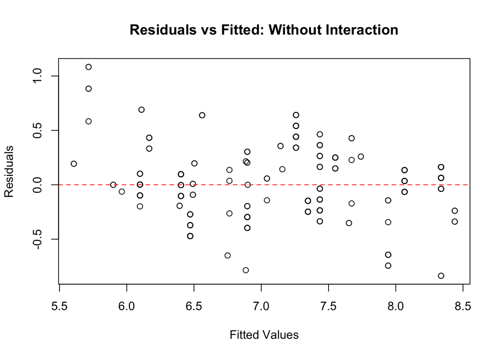

```
Durbin-Watson Test for Independence:

    Durbin-Watson test

data:  current_model_3
DW = 0.89031, p-value < 2.2e-16
alternative hypothesis: true autocorrelation is greater than 0
```

```
# Comparison of Model Performance Indices

Name        | Model | AIC (weights) | AICc (weights) | BIC (weights) |    R2 | R2 (adj.) |  RMSE | Sigma
--------------------------------------------------------------------------------------------------------
model_3     |    lm |  73.6 (>.999) |   76.0 (>.999) | 152.1 (>.999) | 0.899 |     0.893 | 0.253 | 0.260
new_model_3 |    lm | 219.1 (<.001) |  220.1 (<.001) | 270.1 (<.001) | 0.845 |     0.840 | 0.313 | 0.318
```

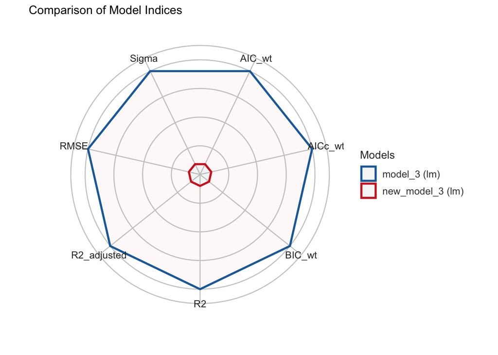

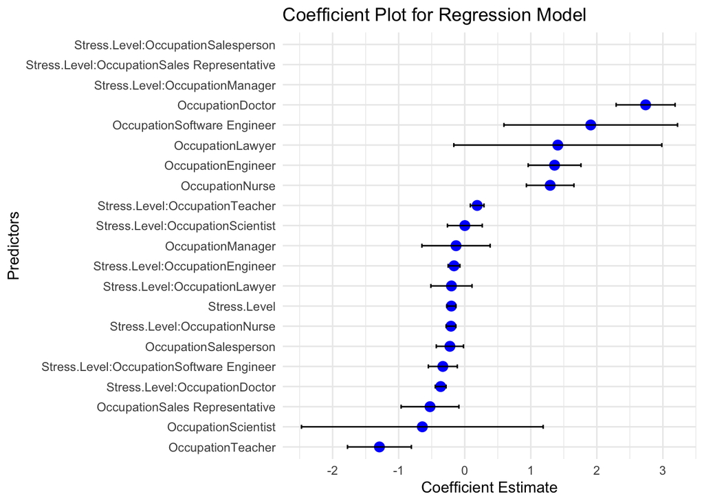

Stress.Level: The negative coefficient indicates that as stress level increases, sleep duration decreases.

Statistical Significance: Predictors with confidence intervals that do not cross zero are statistically significant.

Interaction terms indicate how the effect of stress level on sleep duration varies by occupation.

The negative coefficient for Stress.Level confirms that higher stress levels are significantly associated with shorter sleep durations. This supports the hypothesis that stress negatively impacts sleep.

Interestingly, the healthcare-related occupation (Nurse) does not show a large negative coefficient, suggesting that nurses may not experience as dramatic a reduction in sleep as hypothesized.

# 3 Conclusion and Recommendations

## 3.1 Conclusion

*Question 1.*  
In conclusion, question one examined on the lifestyle factors (e.g., stress level, physical activity, BMI, and daily steps) that are most likely to contribute to the development of sleep disorders, we reject the null hypothesis and conclude that at least one of the lifestyle factors significantly contributes to the development of sleep disorders. Higher stress levels and BMI (overweight) and lower daily steps increase the likelihood of sleep disorders, which is partially correct (independent of one another). Contrary to our speculation, higher physical activity levels increased the likelihood of sleep disorders. Our other speculation that stress level would have the strongest influence was incorrect because BMI (overweight) is actually the strongest.

*Question 2.*  
In the research question two, regarding the level of physical activity influencing the quality of sleep across different age groups, we reject the null hypothesis as there is sufficient evidence to suggest an interaction effect between physical activity and age group on sleep quality (F = 62.288, p < .00001). This indicates that the effect of physical activity on sleep quality varies among age groups.

*Question 3.*  
For the last research question, in finding the interaction between stress level and occupation type impacting overall sleep duration, we reject the null hypothesis because the interaction term between stress level and occupation is statistically significant (F = 26.958, p < 0.001), indicating that the effect of stress level on sleep duration varies across occupations.

## 3.2 Recommendations

*Question 1.*  
In the future, we could introduce an interaction term between physical activity level and daily steps to see how it affects the model since there was a correlation between the two variables. We could also explore why higher physical activity levels lead to an increase in development of sleep disorders because scientific studies might suggest otherwise. To improve our model, we can also incorporate more predictor variables and conduct feature selection.

*Question 2.*  
In future models, it is noted to increase the sample size for smaller groups (18–29 only has 19 people, whereas all other groups have significantly higher sample sizes i.e. higher than 100).

*Question 3.*  
In the future, occupations will be grouped into broader categories, such as “high-stress” and “low-stress” jobs, to simplify the analysis and improve interpretability.